# Lab02

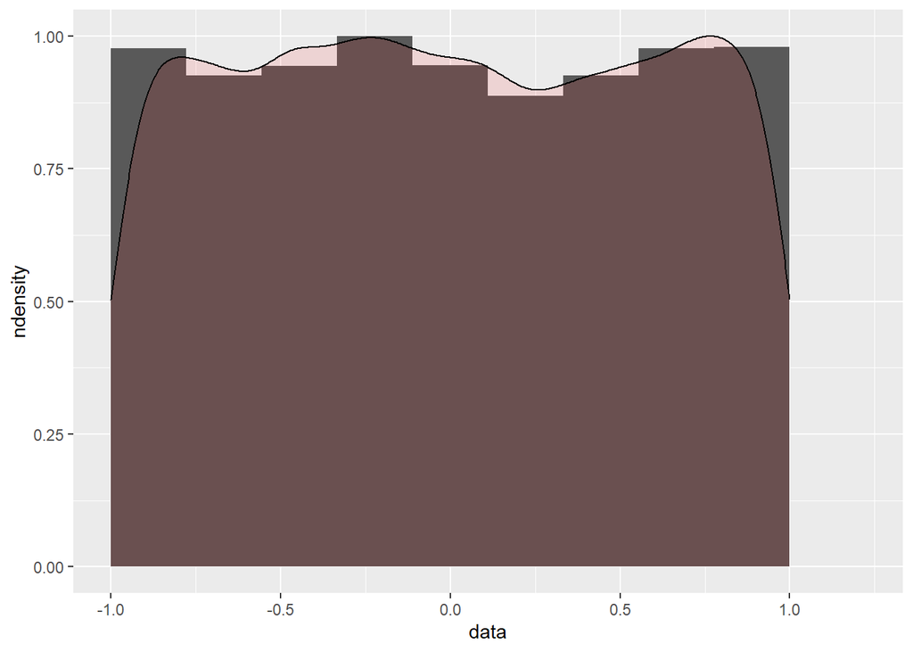

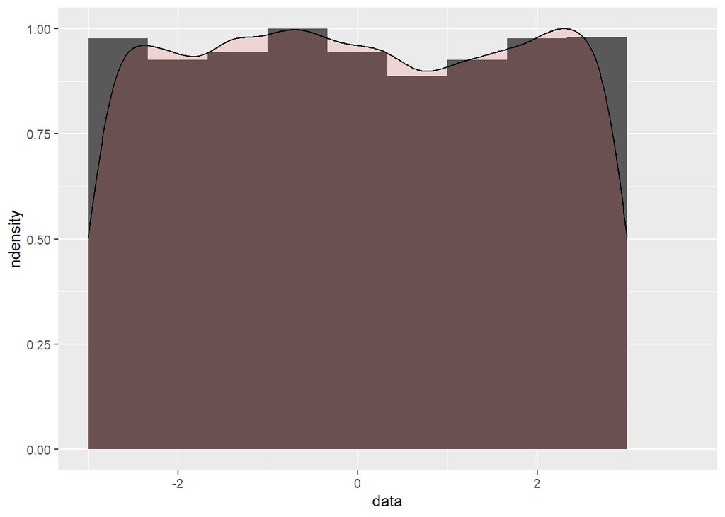

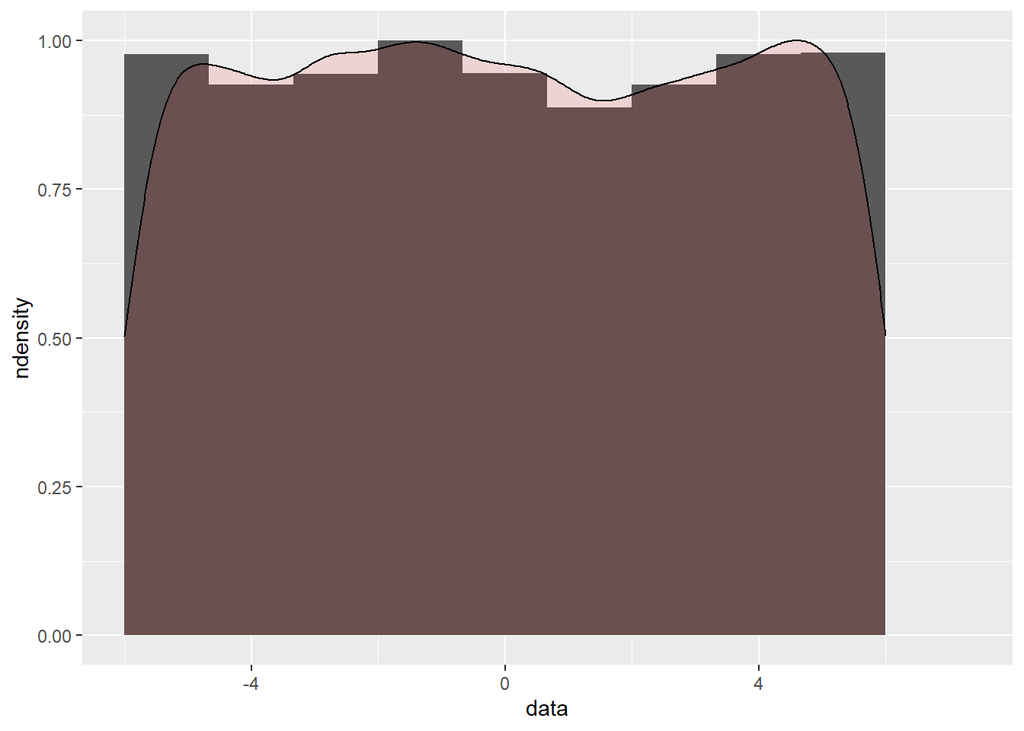

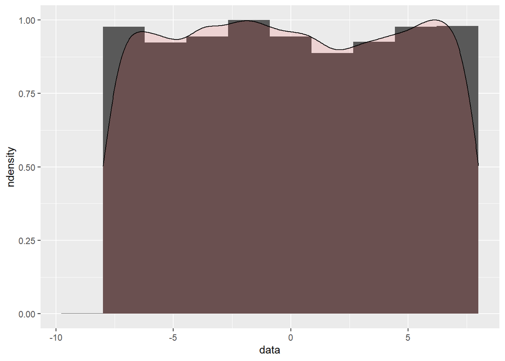

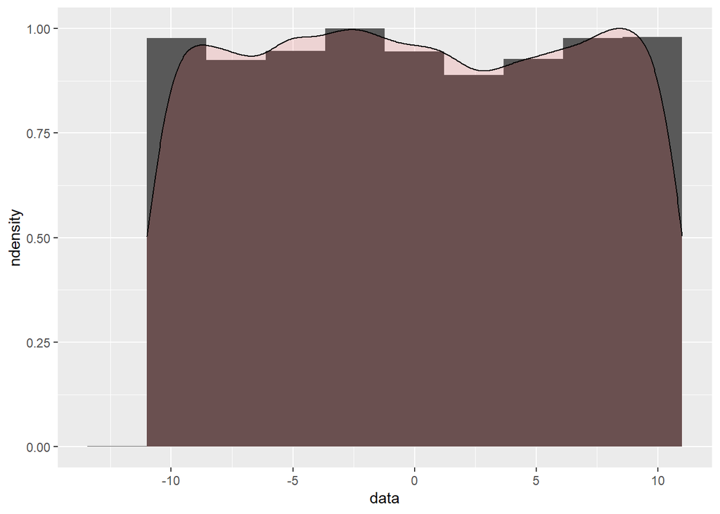

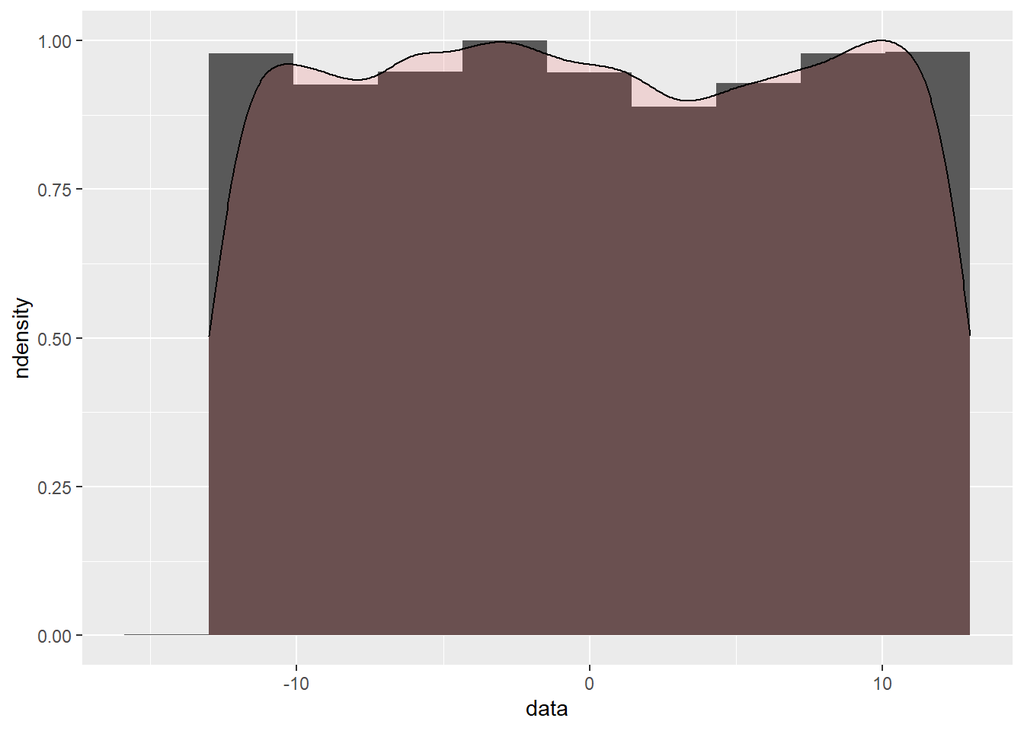

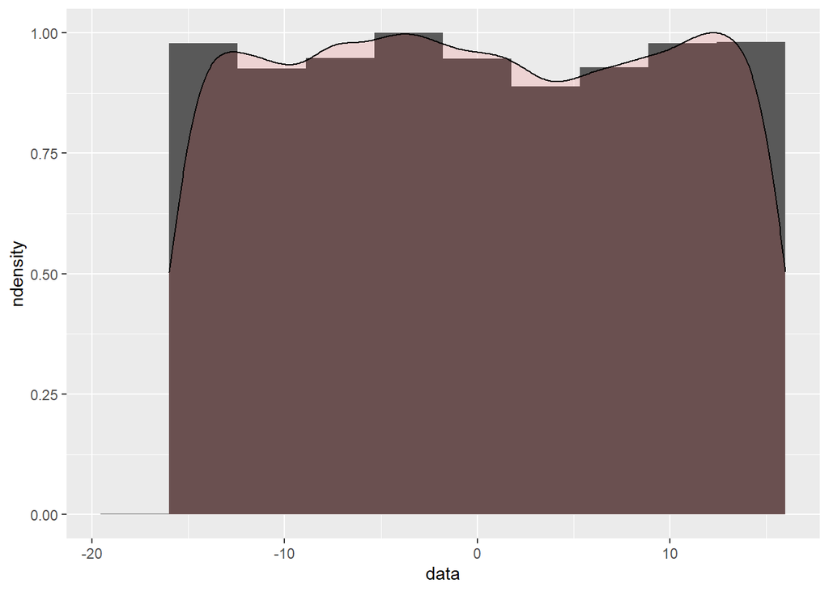

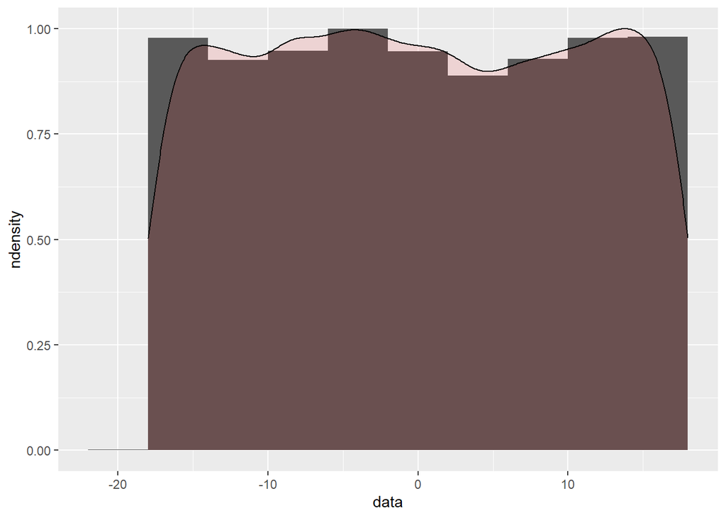

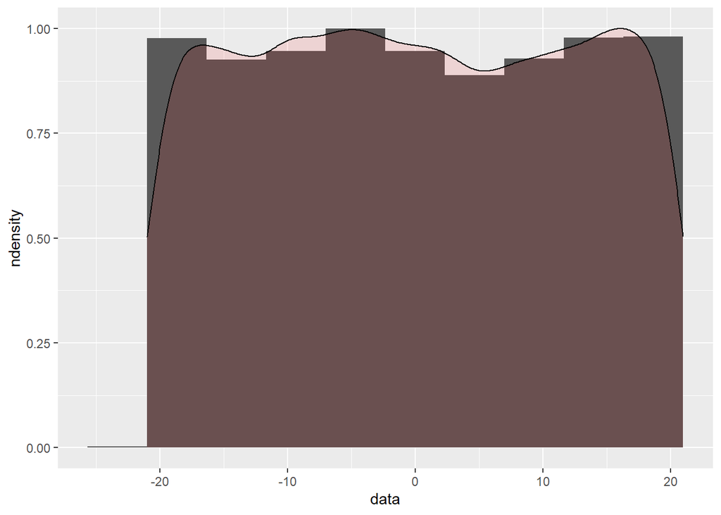

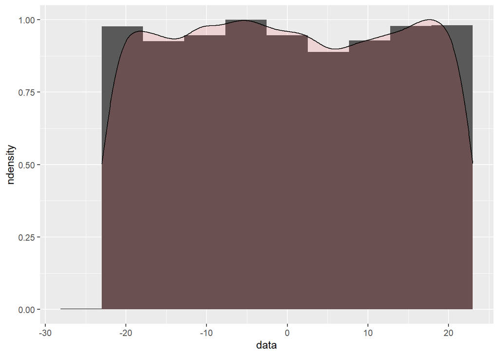

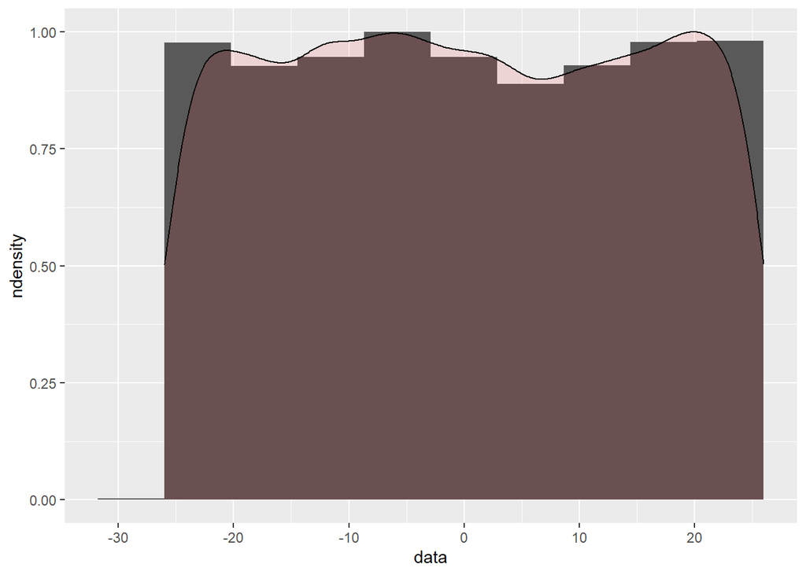

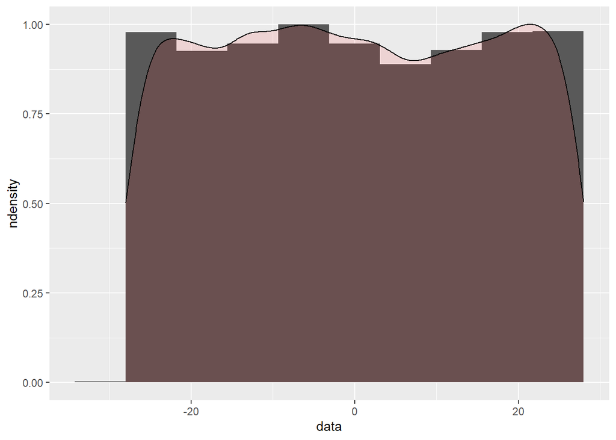

[13 more figures not shown]

```r
set.seed(1)
randomvariables[,1]<-runif(10000,-1,1)
randomvariables[,2]<-2*randomvariables[,1]
randomvariables[,3]<-randomvariables[,1]+randomvariables[,2]
for (i in c(4:N)){
  if(i%%2==0){
  randomvariables[,i] <-randomvariables[,2] +i
  } else{
    randomvariables[,i]<-randomvariables[,3] + i
  }
  randomvariables[,i]<-randomvariables[,i]-mean(randomvariables[,i])
}
dependentrv<-tbl_df(data=randomvariables)

pdf(dependentrv,ydependent)
```

```r
rm(i,N,samplespace,samplespacemixed,dependentrv,randomvariables)
```

#Q. 2: Sampling distribution of mean: A manufacturing process produces cylindrical component parts for the automobile industry. It is required to produce the parts with a mean diameter of 5.0 mm. It is known that the population standard deviation is σ = 0.1 mm. The engineer involved conjectures that the population mean is 5.0 mm.

```r
mean = 5.0 #a+b/2
sd = 0.1 #variance = (b-a)^2/12
b=round(5+0.1*sqrt(3),2)
a=10-b
```

A)An experiment is conducted in which 100 parts produced are selected randomly and the diameter measured in each. Generate uniformly distributed 100 random numbers to represent the diameter using available information and compute a sample average diameter. Does this sample information appear to support or refute the engineer’s conjecture? Draw necessary plots.

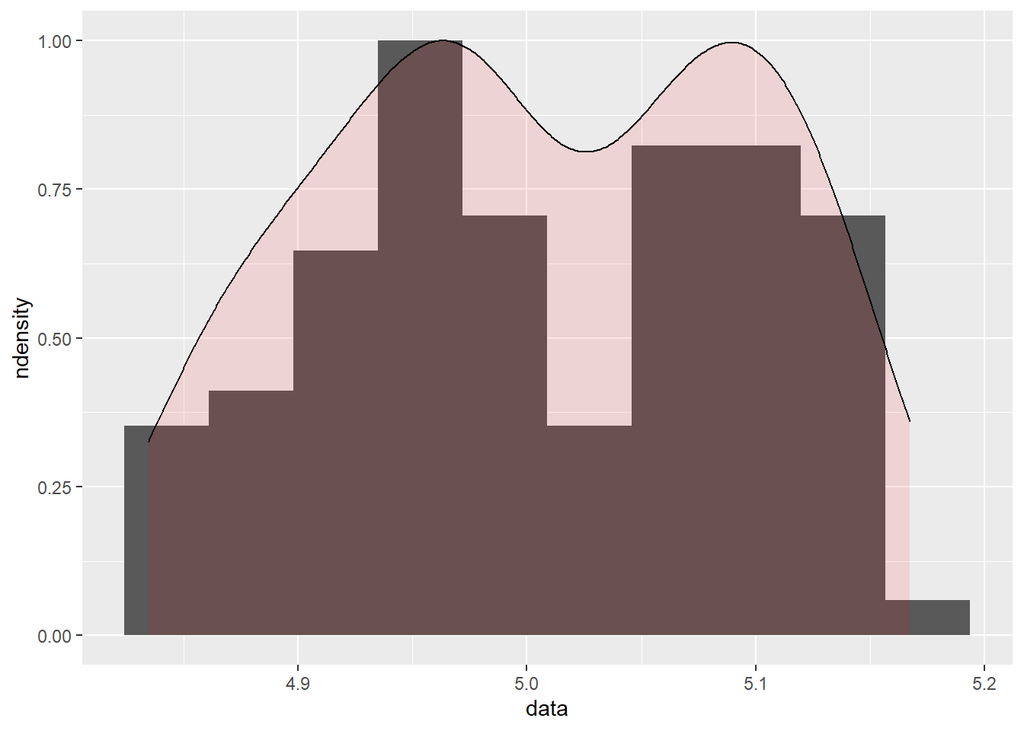

```r
set.seed(1)
diameter<-runif(100,min=a,max=b)
sampleavgdiameter<-mean(diameter)
samplevariance<-var(diameter)
plot_histogram(diameter)
```

```r
zs<-(sampleavgdiameter-mean)/sd #zscore
pnorm(zs) #Getting the probability value
```

```
## [1] 0.524193
```

(B)Generate the sampling distribution of mean by repeating the above random experiment several times. Based on the sample mean obtained thus, comment on the engineer’s conjecture? Draw necessary plots.

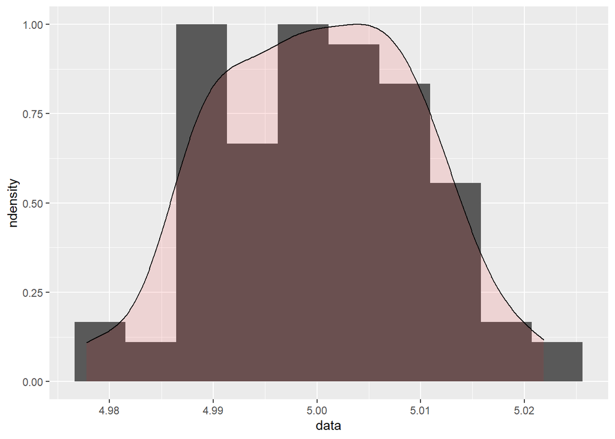

```r
set.seed(1)
samplingmean<-function(s,n,a=4.83,b=5.17){ #s is no of simulation and n is the no of trials
  meantable<-matrix(data=NA, nrow = s,ncol=3)
  colnames(meantable)<-c('Mean','Zscore','PVAL')
  for (i in c(1:s)){
    diameter<-diameter<-runif(n,min=a,max=b)
    meantable[i,1]<-mean(diameter)
    meantable[i,2]<-(mean(diameter)-(a+b)/2)/(0.1/sqrt(n))
    meantable[i,3]<-pnorm(meantable[i,2])
  }
  plot_histogram(meantable[,1])
  return(meantable)
}
data<-samplingmean(100,100)
```

```r
summary(data)
```

```
##       Mean           Zscore               PVAL
##  Min.   :4.978   Min.   :-2.224208   Min.   :0.01307
##  1st Qu.:4.992   1st Qu.:-0.783301   1st Qu.:0.21673
##  Median :5.000   Median :-0.011866   Median :0.49527
##  Mean   :5.000   Mean   : 0.005711   Mean   :0.50238
##  3rd Qu.:5.007   3rd Qu.: 0.679294   3rd Qu.:0.75140
##  Max.   :5.022   Max.   : 2.186395   Max.   :0.98561
```

```r
samplemean<-mean(data[,1])
zs<-(samplemean-mean)/(sd/sqrt(100)) #Z score
print(pnorm(zs))
```

```
## [1] 0.5022784
```

(C)Repeat the part (B) by repeating the random experiment for 10000 parts. Based on the sample mean obtained thus, comment on the engineer’s conjecture? Draw necessary plots.

```r
set.seed(1)
data<-samplingmean(10000,100)
```

[figure not shown]

```r
samplemean<-mean(data[,1])
summary(data)
```

```
##       Mean           Zscore               PVAL
##  Min.   :4.963   Min.   :-3.702059   Min.   :0.0001069
##  1st Qu.:4.993   1st Qu.:-0.673324   1st Qu.:0.2503706
##  Median :5.000   Median :-0.007346   Median :0.4970694
##  Mean   :5.000   Mean   :-0.002643   Mean   :0.4993616
##  3rd Qu.:5.007   3rd Qu.: 0.667746   3rd Qu.:0.7478522
##  Max.   :5.035   Max.   : 3.453801   Max.   :0.9997236
```

```r
  zs<-(samplemean-5.0)/(0.1/sqrt(10000))
  print(pnorm(zs))
```

```
## [1] 0.4894587
```

```r
rm(data,a,b,diameter,mean,sampleavgdiameter,samplemean,samplevariance,sd,zs)
```

#Q-3Sampling distribution of the difference between two means: Consider two populations with certain probability distributions P1(Ω) and P2(Ω). Draw two independent random samples of size n1 and n2 from each population, respectively. Now, generate the sampling distributions of differences of the two means under following cases, and comment on the Normal approximation of the sampling distribution of difference between two means

1. For P1(Ω) ∼ N(5, 1) and P2(Ω) ∼ N(3, 1), and for n1 < 30 and n2 < 30.

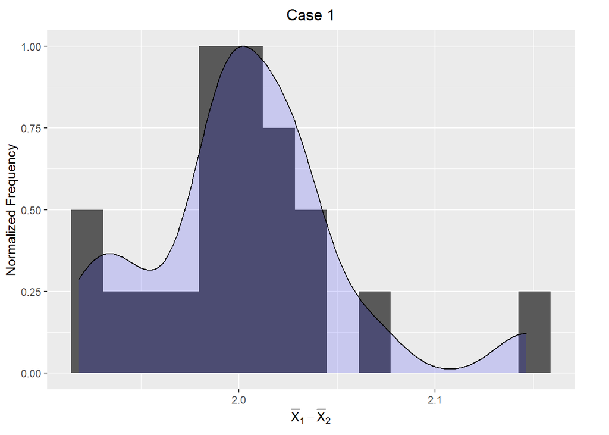

```r
set.seed(1)
library('latex2exp')
n =20
m1 = 5
s1 = 1
m2 = 3
s2 = 1
num_exp = 500
mean_diff = 0 * c(1:n)
for(i in c(1:n)){
  temp1 = rnorm(num_exp, mean = m1, sd = s1)
  temp2 = rnorm(num_exp, mean = m2, sd = s2)
  mean_diff[i] = mean(temp1) - mean(temp2)
}
p1 <- ggplot(data = data.frame(x = mean_diff), aes(x = x))+
  geom_histogram(aes(y = stat(ndensity)), bins = 15)+
  geom_density(aes(y = stat(scaled)), fill = "blue", alpha = 0.15)+
  labs(x = TeX("$\\bar{X}_1 - \\bar{X}_2$"), y = "Normalized Frequency",
       title = "Case 1")+
  theme(plot.title = element_text(hjust = 0.5), plot.margin = unit(c(0.25, 1, 0.25, 0.15), "cm"))
plot(p1)
```

(B)Repeat part (A) for non-normal populations while keeping other settings the same.

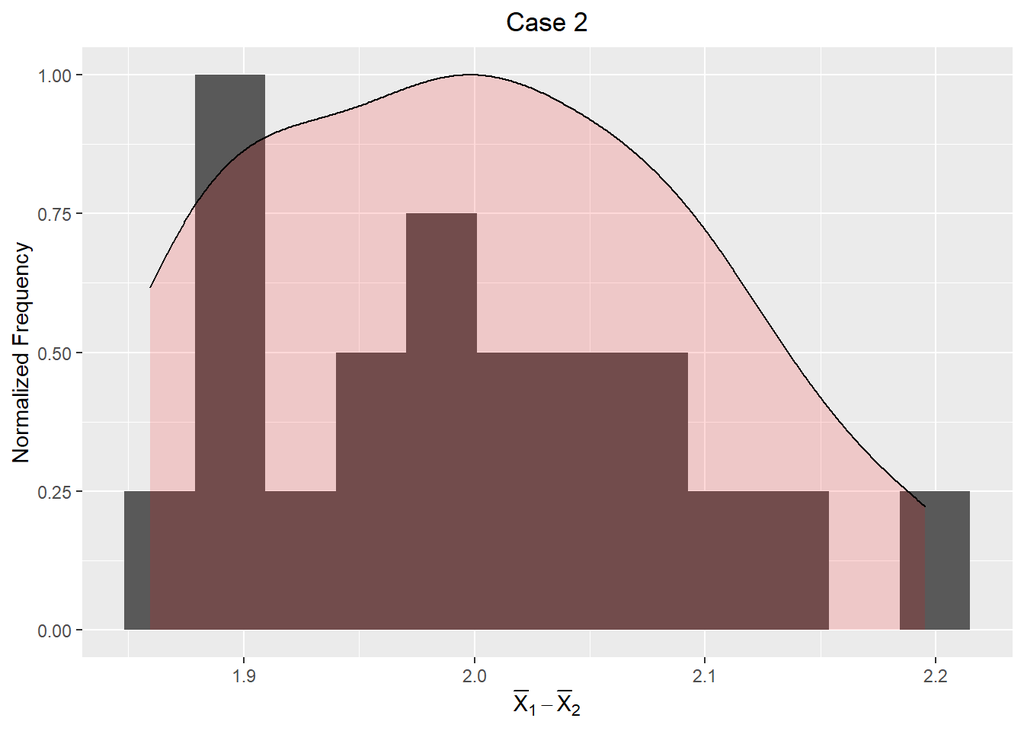

```r
set.seed(1)
n = 20
m1 = 5
s1 = 1
m2 = 3
s2 = 1
num_exp = 500
mean_diff = 0 * c(1:n)
for(i in c(1:n)){
  temp1 = runif(num_exp, min = 2, max = 8)
  temp2 = runif(num_exp, min = 1, max = 5)
  mean_diff[i] = mean(temp1) - mean(temp2)
}
p2 <- ggplot(data = data.frame(x = mean_diff), aes(x = x))+
  geom_histogram(aes(y = stat(ndensity)), bins = 12)+
  geom_density(aes(y = stat(scaled)), fill = "red", alpha = 0.15)+
  labs(x = TeX("$\\bar{X}_1 - \\bar{X}_2$"), y = "Normalized Frequency",
       title = "Case 2")+
  theme(plot.title = element_text(hjust = 0.5))
plot(p2)
```

3. For P1(Ω) ∼ N(5, 1) and P2(Ω) ∼ N(3, 1), and for n1 ≥ 30 and n2 ≥ 30.

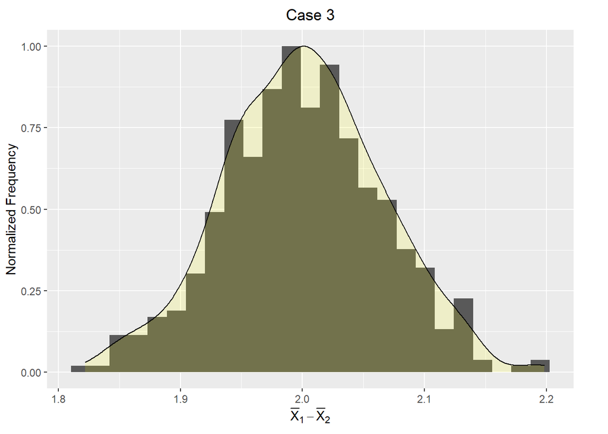

```r
set.seed(1)
n = 500
m1 = 5
s1 = 1
m2 = 3
s2 = 1
num_exp = 500
mean_diff = 0 * c(1:n)
for(i in c(1:n)){
  temp1 = rnorm(num_exp, mean = m1, sd = s1)
  temp2 = rnorm(num_exp, mean = m2, sd = s2)
  mean_diff[i] = mean(temp1) - mean(temp2)
}
p3 <- ggplot(data = data.frame(x = mean_diff), aes(x = x))+
  geom_histogram(aes(y = stat(ndensity)), bins = 25)+
  geom_density(aes(y = stat(scaled)), fill = "yellow", alpha = 0.15)+
  labs(x = TeX("$\\bar{X}_1 - \\bar{X}_2$"), y = "Normalized Frequency",
       title = "Case 3")+
  theme(plot.title = element_text(hjust = 0.5), plot.margin = unit(c(0.25, 1, 0.25, 0.15), "cm"))
plot(p3)
```

4. Repeat part (C) for non-normal populations while keeping other settings the same.

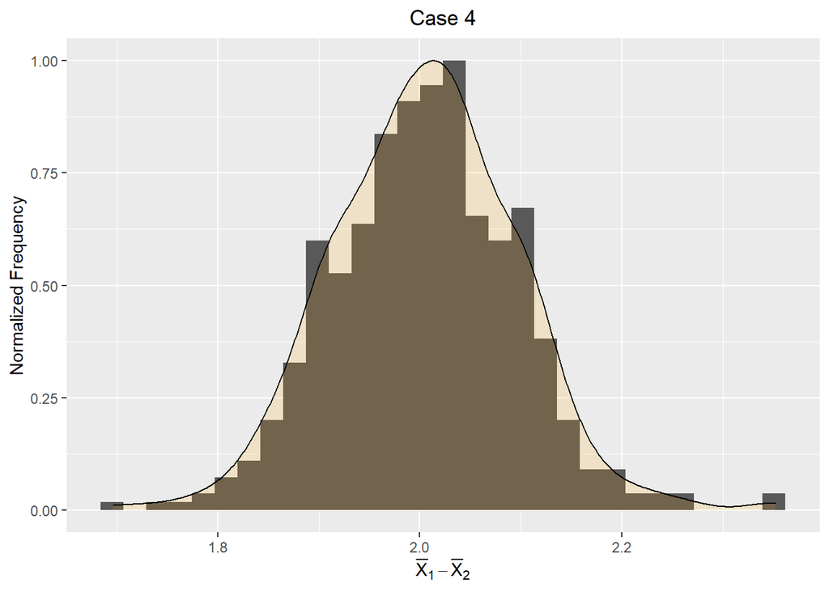

```r
set.seed(1)
n = 500
m1 = 5
s1 = 1
m2 = 3
s2 = 1
num_exp = 500
mean_diff = 0 * c(1:n)
for(i in c(1:n)){
  temp1 = runif(num_exp, min = 2, max = 8)
  temp2 = runif(num_exp, min = 1, max = 5)
  mean_diff[i] = mean(temp1) - mean(temp2)
}
p4 <- ggplot(data = data.frame(x = mean_diff), aes(x = x))+
  geom_histogram(aes(y = stat(ndensity)), bins = 30)+
  geom_density(aes(y = stat(scaled)), fill = "orange", alpha = 0.15)+
  labs(x = TeX("$\\bar{X}_1 - \\bar{X}_2$"), y = "Normalized Frequency",
       title = "Case 4")+
  theme(plot.title = element_text(hjust = 0.5))
plot(p4)
```

Draw all necessary plots for detail illustration.

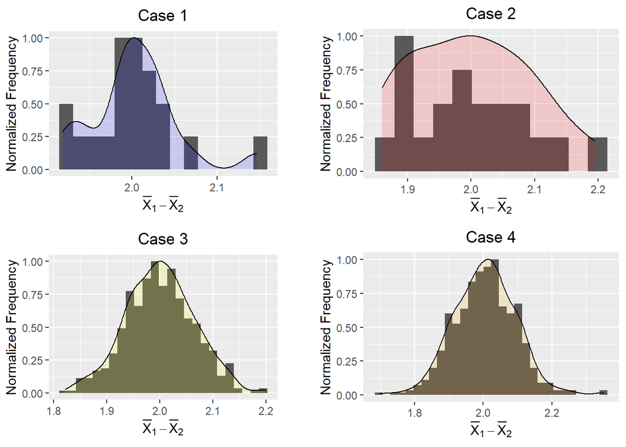

```r
ggarrange(p1, p2, p3, p4, nrow = 2, ncol = 2)
```

```r
rm(i,m1,m2,mean_diff,n,s1,s2,temp1,temp2,p1,p2,p3,p4,num_exp)
```